# Mixed Effects Model Selection: *Crotalus* Strike Speed

Sienna Solis-Stokes

# Introduction

This data set was sourced using [Dryad](https://datadryad.org/) from [Whitford et al. 2020](https://journals.biologists.com/jeb/article/223/14/jeb223859/224523/The-effects-of-temperature-on-the-defensive): “The effects of temperature on the defensive strikes of rattlesnakes”. Whitford et al. conducted repeated laboratory trials to determine how temperature may influence the ability of rattlesnakes to defend themselves against predators. The trials were completed using 24 snakes; 12 western rattlesnakes (*Crotalus oreganus helleri*) and 12 mojave rattlesnakes (*Crotalus scutulatus*). Each snake was tested up to 3 times in each temperature treatment: 15°C, 20°C, 25°C, 30°C, and 35°C. During a trial each snake was presented with a balloon attached to snake hook and reactions were recorded using high speed cameras.

[interactive chart not shown]

# Plots

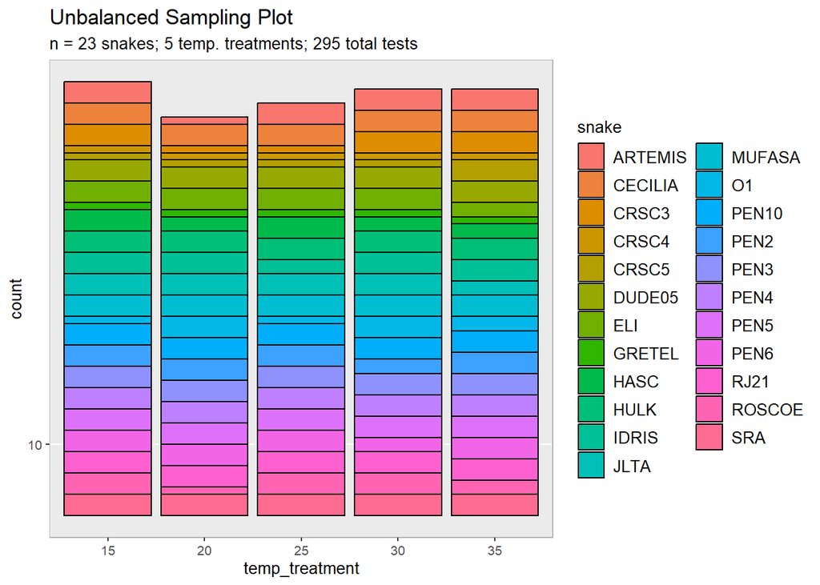

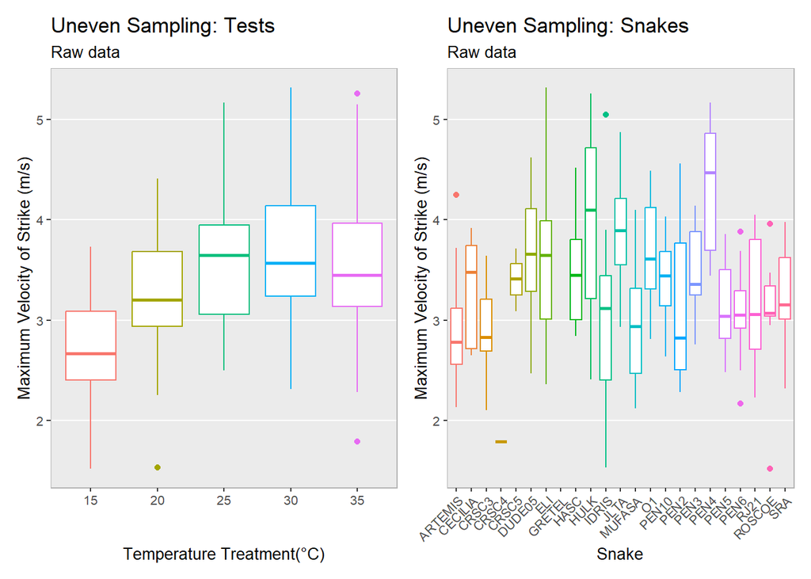

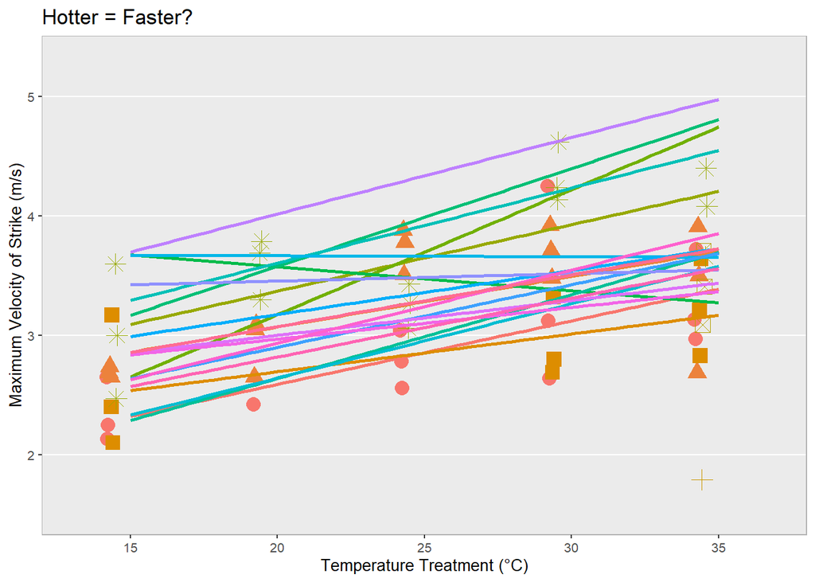

To clean the data for this practice I removed one snake from the data which did not complete trials in all temperatures and replaced NA’s with 0’s in columns where no strike occurred.

I used this data to run a mixed model which accounted for the repeated measures of snakes and the random effect variation between snakes to analyse the fixed effect: temperature treatment.

```r
mixed_treatment <- lmer(neck_max_vel ~ temp_treatment * snake + (1|snake), data = strikes_clean)
anova(mixed_treatment)
```

```
## Type III Analysis of Variance Table with Satterthwaite's method
##                      Sum Sq Mean Sq NumDF DenDF F value    Pr(>F)
## temp_treatment       33.448  8.3619     4   180 19.0965 4.152e-13 ***
## snake                10.275  0.4670    22   180  1.0666    0.3874
## temp_treatment:snake 79.570  0.9042    88   180  2.0650 2.232e-05 ***
## ---
## Signif. codes:  0 '***' 0.001 '**' 0.01 '*' 0.05 '.' 0.1 ' ' 1
```

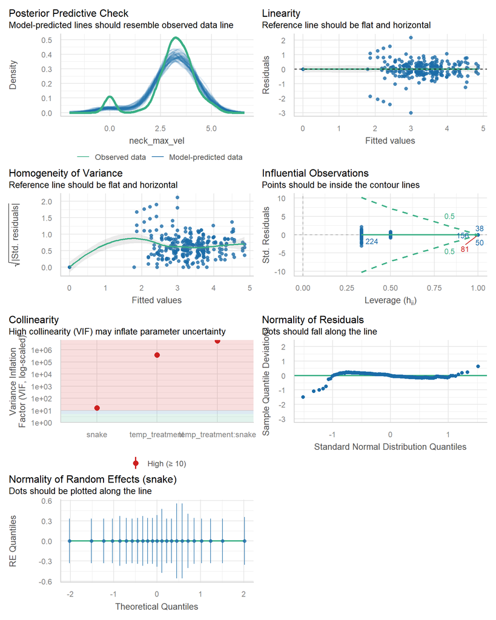

```r
# check the model
performance::check_model(mixed_treatment)
```

To account for the unbalanced data (each snake not completing each temperature trial an equal amount of times), I used the estimated marginal means to plot the mean maximum strike velocity of each temperature treatment.

The gray points represent the raw data means.

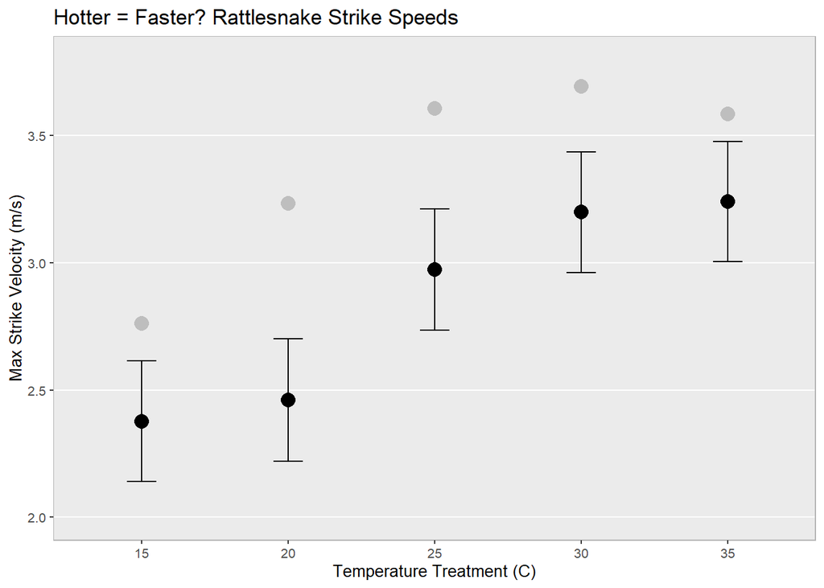

I also wanted to look at the variation between snakes nested within species.

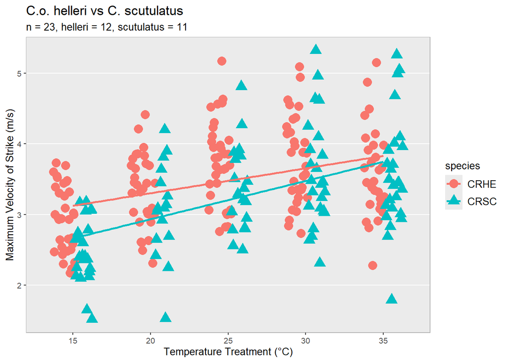

```r
mixed_treatment.spp1 <- lmer(neck_max_vel ~ temp_treatment + (1|snake), data = strikes_clean) # same slopes; random intercepts
mixed_treatment.spp2 <- lmer(neck_max_vel ~ temp_treatment + (species|snake), data = strikes_clean) # random intercepts; random slopes
```

Visualize the data using flexpot:

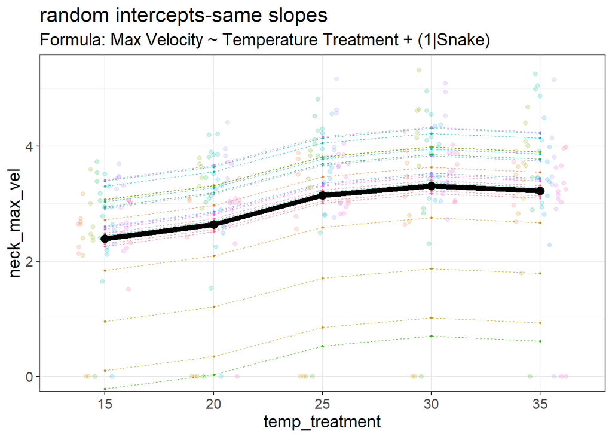

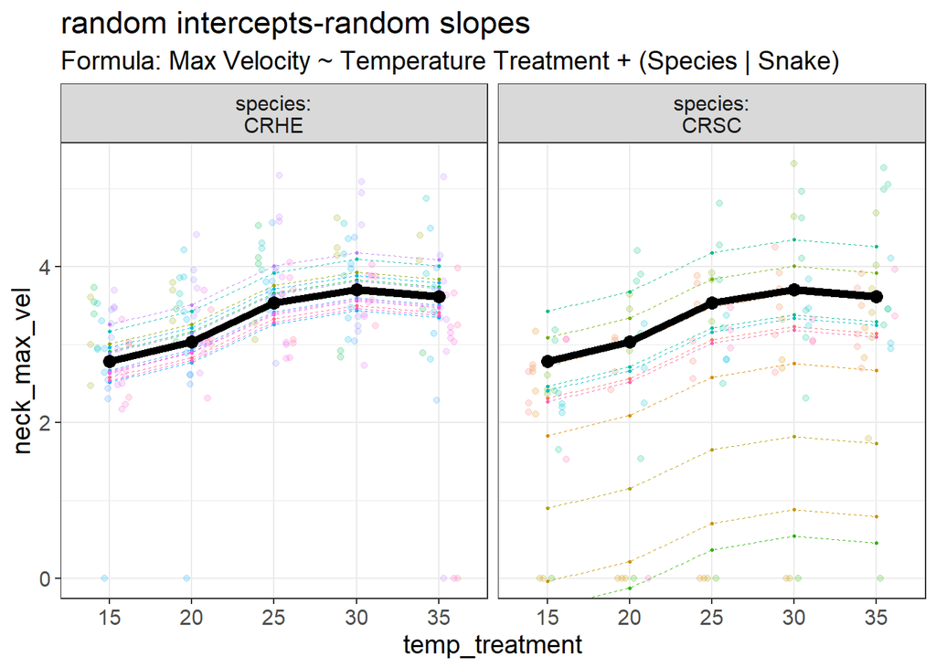

Similar to our example in class, the fixed effect (black line) is the same between the models, but the random effect (snake/snake nested in species) is different.

Next I used the *arm* package to compare intercepts and slopes of the models.

```r
arm::display(mixed_treatment.spp1)
```

```
## lmer(formula = neck_max_vel ~ temp_treatment + (1 | snake), data = strikes_clean)
##                  coef.est coef.se
## (Intercept)      2.39     0.22
## temp_treatment20 0.25     0.14
## temp_treatment25 0.75     0.14
## temp_treatment30 0.92     0.14
## temp_treatment35 0.83     0.14
##
## Error terms:
##  Groups   Name        Std.Dev.
##  snake    (Intercept) 0.97
##  Residual             0.77
## ---
## number of obs: 295, groups: snake, 23
## AIC = 772.1, DIC = 736.6
## deviance = 747.4
```

```r
arm::display(mixed_treatment.spp2)
```

```
## lmer(formula = neck_max_vel ~ temp_treatment + (species | snake),
##     data = strikes_clean)
##                  coef.est coef.se
## (Intercept)      2.78     0.14
## temp_treatment20 0.25     0.14
## temp_treatment25 0.75     0.14
## temp_treatment30 0.92     0.14
## temp_treatment35 0.83     0.14
##
## Error terms:
##  Groups   Name        Std.Dev. Corr
##  snake    (Intercept) 0.31
##           speciesCRSC 1.30     0.56
##  Residual             0.77
## ---
## number of obs: 295, groups: snake, 23
## AIC = 762.1, DIC = 719.8
## deviance = 732.0
```

The model summaries show identical slopes.

Next I used the **parameters* package to compare coefficients.

| Parameter | mixed_treatment.spp1 Coefficient(SE) | mixed_treatment.spp1 p | mixed_treatment.spp2 Coefficient(SE) | mixed_treatment.spp2 p |
| --- | --- | --- | --- | --- |
| (Intercept) | 2.39 (0.22) | <0.001 | 2.78 (0.14) | <0.001 |
| temp treatment (20) | 0.25 (0.14) | 0.082 | 0.25 (0.14) | 0.079 |
| temp treatment (25) | 0.75 (0.14) | <0.001 | 0.75 (0.14) | <0.001 |
| temp treatment (30) | 0.92 (0.14) | <0.001 | 0.92 (0.14) | <0.001 |
| temp treatment (35) | 0.83 (0.14) | <0.001 | 0.83 (0.14) | <0.001 |
| Observations | 295 |  | 295 |  |

Now to compare the models to see which model best explains the results.

```
## # Comparison of Model Performance Indices
##
## Name                 |           Model | AIC (weights) | AICc (weights)
## -----------------------------------------------------------------------
## mixed_treatment.spp1 | lmerModLmerTest | 761.4 (0.003) |  761.8 (0.004)
## mixed_treatment.spp2 | lmerModLmerTest | 750.0 (0.997) |  750.6 (0.996)
##
## Name                 | BIC (weights) | R2 (cond.) | R2 (marg.) |   ICC |  RMSE | Sigma
## --------------------------------------------------------------------------------------
## mixed_treatment.spp1 | 787.2 (0.118) |      0.642 |      0.079 | 0.612 | 0.736 | 0.770
## mixed_treatment.spp2 | 783.2 (0.882) |      0.276 |      0.162 | 0.136 | 0.738 | 0.769
```

# Model Interpretation

Both models were statistically significant in their fixed effect of temperature treatment for all treatments except 20, and this was primarily what we were interested in. Model 2 (lmer(neck_max_vel ~ temp_treatment + (species|snake), data = strikes_clean)) has a lower AIC and a 99% chance of best describing the data. This model removed the random effect of the snake completing the trial nested within the different species, fitting a different slope and intercept for each individual. These results align with the results of Whitford et al. which stated that their results showed an overall faster strike speed as temperature increased for all snakes, the mojave rattlesnakes struck less times overall (125) than the western rattlesnakes (179).